# Predicting Barbell Lifting Performance

Regis O’Connor

December 3, 2016

## Executive Summary

After evaluating 3 different prediction models on the Weight Lifting Exercise Database, a random forest model emerged with the highest accuracy and kappa values The most important variables for prediction of how the barbell was lifted were the forearm pitch and belt roll.

## Background

Using devices such as Jawbone Up, Nike FuelBand, and Fitbit it is now possible to collect a large amount of data about personal activity relatively inexpensively. These type of devices are part of the quantified self movement - a group of enthusiasts who take measurements about themselves regularly to improve their health, to find patterns in their behavior, or because they are tech geeks. One thing that people regularly do is quantify how much of a particular activity they do, but they rarely quantify how well they do it. In this project, your goal will be to use data from accelerometers on the belt, forearm, arm, and dumbell of 6 participants. They were asked to perform barbell lifts correctly and incorrectly in 5 different ways. More information is available from the website here: http://groupware.les.inf.puc-rio.br/har (see the section on the Weight Lifting Exercise Dataset).

## Data Process, Exploratory Data Analysis

```r
training <- read.csv("pml-training.csv")
testing  <- read.csv("pml-testing.csv")

library(caret)
library(randomForest)
set.seed(777)
validation <- createDataPartition(y=training$classe, p=0.2, list=FALSE)
validtrain <- training[validation,]
train      <- training[-validation,]

summary(train)
```

[output not shown]

[output cut: 305 more lines]

[output not shown]

```r
library(dplyr)
smalltrain <- train %>% select(-starts_with("kurtosis")) %>%
  select(-starts_with("skewness")) %>%
  select(-starts_with("max"))%>%
  select(-starts_with("min"))%>%
  select(-starts_with("amplitude"))%>%
  select(-starts_with("var"))%>%
  select(-starts_with("avg"))%>%
  select(-starts_with("stddev"))
smalltest  <- testing %>% select(-starts_with("kurtosis")) %>%
  select(-starts_with("skewness")) %>%
  select(-starts_with("max"))%>%
  select(-starts_with("min"))%>%
  select(-starts_with("amplitude"))%>%
  select(-starts_with("var"))%>%
  select(-starts_with("avg"))%>%
  select(-starts_with("stddev"))
smallvalid <- validtrain %>% select(-starts_with("kurtosis")) %>%
  select(-starts_with("skewness")) %>%
  select(-starts_with("max"))%>%
  select(-starts_with("min"))%>%
  select(-starts_with("amplitude"))%>%
  select(-starts_with("var"))%>%
  select(-starts_with("avg"))%>%
  select(-starts_with("stddev"))
```

## Model Selection Strategy

Given the categorical nature of the outcome the 3 models considered were random forest, rpart and linear discriminant analysis. Random Forest delivered the highest Accuracy and Kappa metrics, but did require substantial processing time - at least an hour. Both rpart and lda were much faster but far less accurate. The rf model was validated on the validation subset to confirm performance, and then used with the test data. Note that these models exclude the first 7 variables which were used for sample identification.

```r
mod1  <- train(classe~., data=smalltrain[,8:60], method="rf")
mod2  <- train(classe~., data=smalltrain[,8:60], method="rpart")
mod3  <- train(classe~., data=smalltrain[,8:60], method = "lda")
pred1 <- predict(mod1, smallvalid)
pred2 <- predict(mod2, smallvalid)
pred3 <- predict(mod3, smallvalid)

confusionMatrix(pred1, smallvalid$classe)
```

```
## Confusion Matrix and Statistics
##
##           Reference
## Prediction    A    B    C    D    E
##          A 1116    4    0    0    0
##          B    0  755    2    0    0
##          C    0    1  679    4    2
##          D    0    0    4  640    5
##          E    0    0    0    0  715
##
## Overall Statistics
##
##                Accuracy : 0.9944
##                  95% CI : (0.9915, 0.9965)
##     No Information Rate : 0.2842
##     P-Value [Acc > NIR] : < 2.2e-16
##
##                   Kappa : 0.9929
##  Mcnemar's Test P-Value : NA
##
## Statistics by Class:
##
##                      Class: A Class: B Class: C Class: D Class: E
## Sensitivity            1.0000   0.9934   0.9912   0.9938   0.9903
## Specificity            0.9986   0.9994   0.9978   0.9973   1.0000
## Pos Pred Value         0.9964   0.9974   0.9898   0.9861   1.0000
## Neg Pred Value         1.0000   0.9984   0.9981   0.9988   0.9978
## Prevalence             0.2842   0.1935   0.1744   0.1640   0.1839
## Detection Rate         0.2842   0.1923   0.1729   0.1630   0.1821
## Detection Prevalence   0.2852   0.1928   0.1747   0.1653   0.1821
## Balanced Accuracy      0.9993   0.9964   0.9945   0.9955   0.9952
```

```r
confusionMatrix(pred2, smallvalid$classe)
```

```
## Confusion Matrix and Statistics
##
##           Reference
## Prediction    A    B    C    D    E
##          A 1004  330  308  299  103
##          B   18  238   26  101   93
##          C   90  192  351  244  202
##          D    0    0    0    0    0
##          E    4    0    0    0  324
##
## Overall Statistics
##
##                Accuracy : 0.4882
##                  95% CI : (0.4724, 0.5039)
##     No Information Rate : 0.2842
##     P-Value [Acc > NIR] : < 2.2e-16
##
##                   Kappa : 0.3312
##  Mcnemar's Test P-Value : NA
##
## Statistics by Class:
##
##                      Class: A Class: B Class: C Class: D Class: E
## Sensitivity            0.8996  0.31316  0.51241    0.000  0.44875
## Specificity            0.6300  0.92485  0.77545    1.000  0.99875
## Pos Pred Value         0.4912  0.50000  0.32530      NaN  0.98780
## Neg Pred Value         0.9405  0.84874  0.88272    0.836  0.88941
## Prevalence             0.2842  0.19353  0.17443    0.164  0.18386
## Detection Rate         0.2557  0.06061  0.08938    0.000  0.08251
## Detection Prevalence   0.5205  0.12121  0.27476    0.000  0.08352
## Balanced Accuracy      0.7648  0.61900  0.64393    0.500  0.72375
```

```r
confusionMatrix(pred3, smallvalid$classe)
```

```
## Confusion Matrix and Statistics
##
##           Reference
## Prediction   A   B   C   D   E
##          A 897  99  72  37  22
##          B  34 485  55  23 110
##          C  91 105 446  80  63
##          D  86  32  96 479  77
##          E   8  39  16  25 450
##
## Overall Statistics
##
##                Accuracy : 0.7021
##                  95% CI : (0.6875, 0.7163)
##     No Information Rate : 0.2842
##     P-Value [Acc > NIR] : < 2.2e-16
##
##                   Kappa : 0.6235
##  Mcnemar's Test P-Value : < 2.2e-16
##
## Statistics by Class:
##
##                      Class: A Class: B Class: C Class: D Class: E
## Sensitivity            0.8038   0.6382   0.6511   0.7438   0.6233
## Specificity            0.9182   0.9299   0.8954   0.9114   0.9725
## Pos Pred Value         0.7959   0.6860   0.5682   0.6221   0.8364
## Neg Pred Value         0.9218   0.9146   0.9239   0.9477   0.9197
## Prevalence             0.2842   0.1935   0.1744   0.1640   0.1839
## Detection Rate         0.2284   0.1235   0.1136   0.1220   0.1146
## Detection Prevalence   0.2870   0.1800   0.1999   0.1961   0.1370
## Balanced Accuracy      0.8610   0.7840   0.7733   0.8276   0.7979
```

The final predictions provide the missing values for the 20 test cases

```r
 predtest <- predict(mod1, smalltest)
predtest
```

```
##  [1] B A B A A E D B A A B C B A E E A B B B
## Levels: A B C D E
```

The last exercise identifies the 20 most important variables in this random forest model:

```r
varImp(mod1)
```

```
## rf variable importance
##
##   only 20 most important variables shown (out of 52)
##
##                      Overall
## roll_belt            100.000
## pitch_forearm         59.032
## yaw_belt              52.853
## magnet_dumbbell_y     44.978
## magnet_dumbbell_z     42.865
## pitch_belt            42.017
## roll_forearm          41.563
## accel_dumbbell_y      23.694
## magnet_dumbbell_x     16.275
## accel_forearm_x       16.263
## roll_dumbbell         15.974
## magnet_belt_z         15.062
## total_accel_dumbbell  13.797
## magnet_forearm_z      13.762
## accel_dumbbell_z      12.884
## accel_belt_z          12.829
## magnet_belt_y         11.466
## gyros_belt_z          11.057
## yaw_arm               10.186
## magnet_belt_x          9.347
```

This final plot provides further insight into the dynamics of the top 2 variables and the type of performance in the weight lifting exercise.

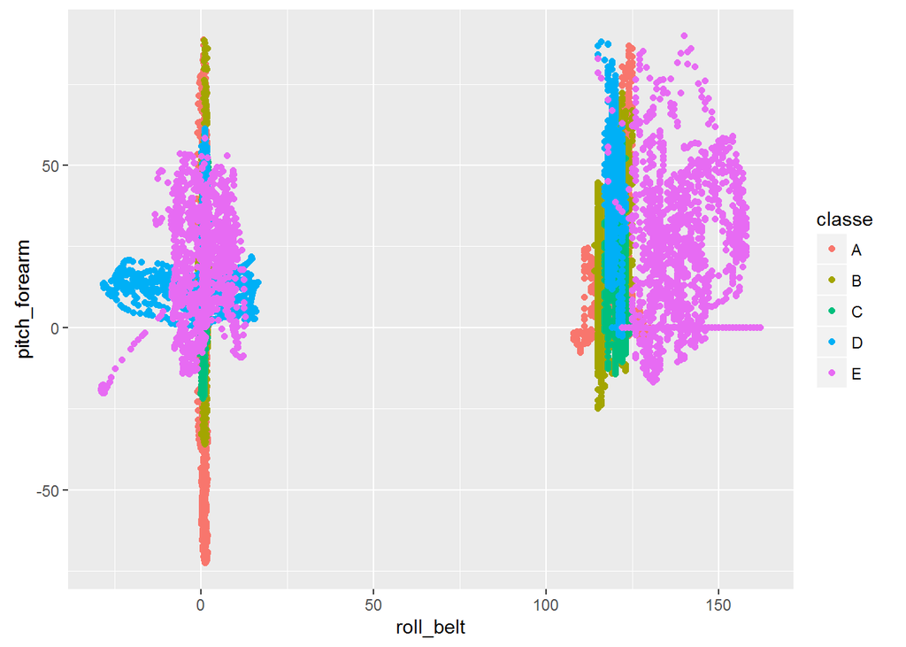